# SOC301B — R Cheatsheet (1): Programming

Everything we’ve seen so far, in one place

# 1. How to use this document

You’ve seen a lot in a few weeks. Let us now take the time to *organize* what you’ve learned. This document does that for you.

Every section works the same way: a short explanation, then a chunk of code you can copy, applied to the **Titanic dataset**. To adapt it to your own data, you usually just need to change the name of the dataset and the names of the variables.

See this document as a cheatsheet: use it along side your exercises for help. I also recommend reading it at least once from beginning to end.

*This is part 1 of the cheatsheet: **programming**. Part 2 covers **statistics** (descriptive vs inferential statistics, linear regression, correlation).*

*NB: To run the chunks of this document yourself, put `titanic.csv` and `threat reactivity.csv` in the same folder as this .qmd file.*

**Reminder: the Titanic variables**

| Variable | Description | Notes |
| --- | --- | --- |
| `PassengerId` | Passenger ID | — |
| `Survived` | Survival | 0 = No; 1 = Yes |
| `Pclass` | Passenger class | 1 = 1st; 2 = 2nd; 3 = 3rd |
| `Name` | Name | — |
| `Sex` | Sex | “female” / “male” |
| `Age` | Age | in years; has missing values |
| `SibSp` | Siblings/Spouses aboard | number |
| `Parch` | Parents/Children aboard | number |
| `Ticket` | Ticket number | — |
| `Fare` | Passenger fare | British pounds |
| `Cabin` | Cabin | often empty |
| `Embarked` | Port of embarkation | C = Cherbourg; Q = Queenstown; S = Southampton |

# 2. Workflow: before you write any code

Most of the problems you’ll meet at the beginning are not about code. They’re about organization: R can’t find your file, the document doesn’t render, a package is missing. This section is about setting things up properly, so that these problems don’t happen.

## 2.1 The working directory

When you ask R to open a file (`read.csv("titanic.csv")`), it doesn’t search your whole computer. It only looks in **one** folder: the **working directory**. It’s also where R saves the files it produces (your .html, your plots). If your dataset is not in this folder, R simply can’t see it, even if it’s on your Desktop, one click away.

So the rule is simple: **your script (.qmd), your dataset (.csv), and your outputs (.html, plots) should all be in the same folder**, and this folder should be your working directory.

The easiest way to do this properly is to create an **R Project**: File → New Project → New Directory → New Project, then choose where to create the folder. This creates a folder with a `.Rproj` file inside. From now on, always open your work by double-clicking on this `.Rproj` file: R automatically sets the working directory to this folder. Put your dataset and your .qmd files inside it, and you’ll never have to think about it again.

If R tells you it can’t find your dataset, the first thing to do is to check where R is currently looking:

```r
getwd()
```

`getwd()` stands for “get working directory”. It prints the path of the folder R is looking in. If it’s not your project folder, that’s why R can’t find your dataset.

*NB: If you open a .qmd file and click “Render”, Quarto uses the folder of the .qmd file as the working directory. So the dataset must be in the same folder as the .qmd.*

## 2.2 Quarto (.qmd) files

A .qmd file is a document that mixes text and code. When you render it, R runs the code, and produces a clean document (an .html file) with your text, your code, and its results (tables, plots) all together. This is what makes your work **reproducible**: anyone with your .qmd and your dataset can re-run everything and get exactly the same results.

A .qmd file has three ingredients:

1. **The YAML**: the header between the two `---` at the very top. It sets the title, the output format, and global options (for instance, whether to show the code, or hide warnings). The YAML you need to use by default is the one from the Spotify Template.
2. **Text**: written normally, with `#` for titles, `**bold**`, `*italics*`. The syntax of Quarto is Markdown. This is the same syntax used in other software like Notion.
3. **Code chunks**: blocks of R code, between `` ```{r} `` and `` ``` ``. This is where everything happens. Insert one with **Ctrl + Alt + I** (Mac: **Cmd + Option + I**).

You’ll see `#| eval: false` a lot in this cheatsheet: it’s for code that I want to show you, but that shouldn’t run when the document is rendered (like `install.packages()`).

**Rendering.** “Render” (the blue arrow button) runs the whole document *from scratch*, top to bottom, and produces the .html file. “From scratch” is important: Render doesn’t care about what you did in the console, or about the objects in your Environment. It starts from an empty R, and only runs what’s written in the .qmd. That’s why something can work when you run it by hand, but fail when you render (see the Advice section).

If rendering fails, read the error message: it tells you at which line it broke.

## 2.3 Running code

You don’t need to render the whole document every time you want to test something. While you work, you run your code piece by piece, and look at the result immediately. These shortcuts will save you a lot of time:

| What you want | Shortcut |
| --- | --- |
| Run the current line (or selected lines) | Ctrl + Enter (Mac: Cmd + Enter) |
| Run the whole current chunk | Ctrl + Shift + Enter (Mac: Cmd + Shift + Enter) |
| Insert a new chunk | Ctrl + Alt + I (Mac: Cmd + Option + I) |
| Insert the pipe `%>%` | Ctrl + Shift + M (Mac: Cmd + Shift + M) |
| Get help on a function | type `?function_name` in the console, e.g. `?filter` |

The usual way of working: write a few lines, run them, check the result, then continue. Don’t write 50 lines before running anything: if something breaks, you won’t know where.

## 2.4 Packages

R comes with a set of basic functions (`mean()`, `nrow()`, `read.csv()`…). But most of the functions we use in this class (`filter()`, `ggplot()`, `kable()`…) were written by other people, and shared as **packages**. A package is a set of functions someone else wrote.

Think of it like an app on your phone: you **install** it once, but you have to **open** it each time you want to use it.

**Installing** downloads the package on your computer. You only do it once, in the console:

```r
install.packages("tidyverse") # once, in the console. NOT in your .qmd!
```

**Loading** makes the functions of the package available in your current R session. You do it every time you open R, at the top of your .qmd:

```r
library(tidyverse) # every time, at the top of your .qmd
library(knitr)     # for kable() tables
```

If you forget to load a package, R will tell you `could not find function "..."`. It doesn’t mean the function doesn’t exist: it means R doesn’t know it yet, because the package isn’t loaded.

*NB: Never leave `install.packages()` in a .qmd file: it will reinstall the package every time you render, which is a waste of time.*

*NB: Notice that `install.packages()` takes quotes (`"tidyverse"`), but `library()` doesn’t (`tidyverse`).*

## 2.5 Starting from a clean slate

As you work, your Environment (top right) fills up with objects: datasets, intermediate results, tests. Some of them may come from old versions of your code that you’ve since changed or deleted. The problem: your code may *seem* to work only because it relies on one of these leftover objects. The day you render or restart R, it breaks.

This line removes everything from your environment (all datasets, all variables). Useful at the top of a script, to make sure nothing “left over” from earlier influences your results.

```r
rm(list = ls())
```

The more radical (and better) version: **Session → Restart R**, then run your code from the very beginning. This also unloads all packages, so you check that your `library()` lines are there too.

# 3. Loading and inspecting a dataset

Before analyzing anything, you need to get your data into R, and then *look at it*. This second step is often skipped, and it’s a mistake: most errors in data analysis come from data that is not what you think it is (a variable stored as text, missing values, strange codes). A few minutes of inspection save hours of confusion later.

## 3.1 Load a dataset

Datasets usually come as **.csv** files (“comma-separated values”): a simple text file where each line is a row, and values are separated by commas. You can open it in Excel, but in R, we load it with `read.csv()`:

```r
data = read.csv("titanic.csv")
```

This reads the file `titanic.csv` (which must be in your working directory) and stores it in an object called `data`. You’ll see it appear in the “Environment” tab, top right, with its number of observations (rows) and variables (columns).

`data` is just a name: you could call it `titanic` or `passengers`. What matters is that you use the same name afterwards. From now on, every time you write `data`, R knows you’re talking about this dataset.

*NB: The name of the file must be exact, with the extension, between quotes: `"titanic.csv"`, not `titanic` or `"Titanic.csv"`.*

*NB: `=` and `<-` do exactly the same thing here. Use whichever you prefer, but it’s better to be consistent.*

## 3.2 Look at the dataset

Now that the data is loaded, look at it. Always do at least one of these before starting any analysis.

**See the dataset like a spreadsheet.** The most intuitive way: R opens the dataset in a new tab, and you can scroll through it, sort columns, and search.

```r
View(data) # or click on "data" (or whatever other name for a dataframe) in the Environment tab on the top right
```

**The structure: variable names, their type, and the first values.** This is the most useful overview: in one glance, you see all the variables, and how R understood them.

```r
glimpse(data) # or str(data)
```

```
Rows: 891
Columns: 12
$ PassengerId <int> 1, 2, 3, 4, 5, 6, 7, 8, 9, 10, 11, 12, 13, 14, 15, 16, 17,…
$ Survived    <int> 0, 1, 1, 1, 0, 0, 0, 0, 1, 1, 1, 1, 0, 0, 0, 1, 0, 1, 0, 1…
$ Pclass      <int> 3, 1, 3, 1, 3, 3, 1, 3, 3, 2, 3, 1, 3, 3, 3, 2, 3, 2, 3, 3…
$ Name        <chr> "Braund, Mr. Owen Harris", "Cumings, Mrs. John Bradley (Fl…
$ Sex         <chr> "male", "female", "female", "female", "male", "male", "mal…
$ Age         <dbl> 22, 38, 26, 35, 35, NA, 54, 2, 27, 14, 4, 58, 20, 39, 14, …
$ SibSp       <int> 1, 1, 0, 1, 0, 0, 0, 3, 0, 1, 1, 0, 0, 1, 0, 0, 4, 0, 1, 0…
$ Parch       <int> 0, 0, 0, 0, 0, 0, 0, 1, 2, 0, 1, 0, 0, 5, 0, 0, 1, 0, 0, 0…
$ Ticket      <chr> "A/5 21171", "PC 17599", "STON/O2. 3101282", "113803", "37…
$ Fare        <dbl> 7.2500, 71.2833, 7.9250, 53.1000, 8.0500, 8.4583, 51.8625,…
$ Cabin       <chr> "", "C85", "", "C123", "", "", "E46", "", "", "", "G6", "C…
$ Embarked    <chr> "S", "C", "S", "S", "S", "Q", "S", "S", "S", "C", "S", "S"…
```

Pay attention to the **type** of each variable, written between `< >`. It tells you how R will treat it:

- `int` / `dbl`: numbers (integers / decimals). You can compute means, etc.
- `chr`: text (“character”). You can’t compute a mean on text.
- `fct`: categories, called “factors”.
- `lgl`: TRUE/FALSE (“logical”).

If a variable that should be a number shows `<chr>`, you’ll need to convert it (see section 5.5).

**A quick summary of each variable.** For numbers: min, max, mean, median, quartiles, and the number of missing values (`NA's`). It’s a fast way to spot strange values (a negative age, a maximum way too high…).

```r
summary(data)
```

```
  PassengerId       Survived          Pclass             Name
 Min.   :  1.0   Min.   :0.0000   Min.   :1.000   Length   :891
 1st Qu.:223.5   1st Qu.:0.0000   1st Qu.:2.000   N.unique :891
 Median :446.0   Median :0.0000   Median :3.000   N.blank  :  0
 Mean   :446.0   Mean   :0.3838   Mean   :2.309   Min.nchar: 12
 3rd Qu.:668.5   3rd Qu.:1.0000   3rd Qu.:3.000   Max.nchar: 82
 Max.   :891.0   Max.   :1.0000   Max.   :3.000

        Sex           Age            SibSp           Parch
 Length   :891   Min.   : 0.42   Min.   :0.000   Min.   :0.0000
 N.unique :  2   1st Qu.:20.12   1st Qu.:0.000   1st Qu.:0.0000
 N.blank  :  0   Median :28.00   Median :0.000   Median :0.0000
 Min.nchar:  4   Mean   :29.70   Mean   :0.523   Mean   :0.3816
 Max.nchar:  6   3rd Qu.:38.00   3rd Qu.:1.000   3rd Qu.:0.0000
                 Max.   :80.00   Max.   :8.000   Max.   :6.0000
                 NAs    :177
       Ticket         Fare              Cabin          Embarked
 Length   :891   Min.   :  0.00   Length   :891   Length   :891
 N.unique :681   1st Qu.:  7.91   N.unique :148   N.unique :  4
 N.blank  :  0   Median : 14.45   N.blank  :687   N.blank  :  2
 Min.nchar:  3   Mean   : 32.20   Min.nchar:  0   Min.nchar:  0
 Max.nchar: 18   3rd Qu.: 31.00   Max.nchar: 15   Max.nchar:  1
                 Max.   :512.33
```

**The first rows.** `head()` shows the first 6 rows: useful to see what the data concretely looks like, without opening the whole dataset.

```r
head(data)
```

| PassengerId | Survived | Pclass | Name | Sex | Age | SibSp | Parch | Ticket | Fare | Cabin | Embarked |
| --- | --- | --- | --- | --- | --- | --- | --- | --- | --- | --- | --- |
| 1 | 0 | 3 | Braund, Mr. Owen Harris | male | 22 | 1 | 0 | A/5 21171 | 7.2500 |  | S |
| 2 | 1 | 1 | Cumings, Mrs. John Bradley (Florence Briggs Thayer) | female | 38 | 1 | 0 | PC 17599 | 71.2833 | C85 | C |
| 3 | 1 | 3 | Heikkinen, Miss. Laina | female | 26 | 0 | 0 | STON/O2. 3101282 | 7.9250 |  | S |
| 4 | 1 | 1 | Futrelle, Mrs. Jacques Heath (Lily May Peel) | female | 35 | 1 | 0 | 113803 | 53.1000 | C123 | S |
| 5 | 0 | 3 | Allen, Mr. William Henry | male | 35 | 0 | 0 | 373450 | 8.0500 |  | S |
| 6 | 0 | 3 | Moran, Mr. James | male | NA | 0 | 0 | 330877 | 8.4583 |  | Q |

## 3.3 Number of rows and columns

How big is the dataset? The number of rows usually tells you how many observations you have (here, passengers), and the number of columns how many variables you have.

```r
nrow(data) # number of rows: here, number of passengers
```

```
[1] 891
```

```r
ncol(data) # number of columns: number of variables
```

```
[1] 12
```

```r
dim(data)  # both at once
```

```
[1] 891  12
```

It’s a good reflex to check `nrow()` again after any transformation that might remove rows (like `filter()`): did you lose the number of observations you expected?

## 3.4 Names of the variables

To write code, you need the **exact** name of each variable, including capital letters: R considers `Age` and `age` as two different things. `names()` lists them all:

```r
names(data)
```

```
 [1] "PassengerId" "Survived"    "Pclass"      "Name"        "Sex"
 [6] "Age"         "SibSp"       "Parch"       "Ticket"      "Fare"
[11] "Cabin"       "Embarked"
```

## 3.5 Select one variable (a column)

Sometimes, you want to work on one single variable. The `$` sign takes one column from a dataset: `dataset$variable`. Read it as “in `data`, take the column `Age`”.

```r
data$Age
```

On its own, this prints all the values of the column, which is not very useful. But you can then apply any function to it. For instance, the mean fare paid by passengers:

```r
mean(data$Fare)
```

```
[1] 32.20421
```

*NB: Inside tidyverse functions (`filter()`, `mutate()`, `ggplot()`…), you don’t need the `$`: you write the variable name directly, because R already knows which dataset you’re talking about. The `$` is for base R functions like `mean()`, `unique()`, or `table()`.*

## 3.6 All the distinct values of a variable

For a categorical variable, you want to know which values it can take. `unique()` lists each distinct value once:

```r
unique(data$Embarked)
```

```
[1] "S" "C" "Q" ""
```

This is the best tool to spot strange values: typos (“female” and “Female”), unexpected codes, or empty values. Here, notice the empty value `""`: two passengers have no port of embarkation recorded. We’ll fix this in section 5.9.

## 3.7 Check for missing values and duplicates

Two last checks before any analysis.

**Missing values.** In R, a missing value is written `NA` (“not available”). They matter because they change your results: a mean computed on a variable with missing values returns `NA` (see section 6.4), and passengers with a missing age can’t be put in an age category. So you need to know where they are, and how many.

**Duplicates.** A duplicate is a row that appears twice, identically. In some datasets, this signals a problem: the same participant recorded twice by mistake, for instance. In that case, they would count double in your analysis.

```r
colSums(is.na(data))  # number of missing values (NA) in each column
```

```
PassengerId    Survived      Pclass        Name         Sex         Age
          0           0           0           0           0         177
      SibSp       Parch      Ticket        Fare       Cabin    Embarked
          0           0           0           0           0           0
```

```r
sum(duplicated(data)) # number of rows that appear twice
```

```
[1] 0
```

`is.na(data)` checks each cell of the dataset (“is it missing?”), and `colSums()` counts the missing cells in each column. `duplicated(data)` checks each row (“is it identical to a previous row?”), and `sum()` counts them.

*NB: Age has 177 missing values. But Cabin shows 0 missing values, even though most cabins are empty! This is because empty text is stored as `""`, not as `NA`. R doesn’t consider `""` as missing. Always check with `unique()` or by looking at the data.*

*NB: Duplicates are not always errors. If your dataset has an identifier (like `PassengerId`), two identical rows are suspicious. But if it has only a few simple variables and no identifier, two different people can perfectly well have exactly the same characteristics. Ask yourself whether two identical rows can be two real, different observations.*

# 4. The pipe and how R “saves” things

## 4.1 The pipe `%>%`

The pipe means “**and then**”. It takes what’s on its left and passes it to the function on its right. It’s very useful to run multiple functions over the same dataframe.

Let’s take the example of filter(): a function that selects rows based on a given criteria. filter() takes two main arguments: the dataset on which it operates, and the condition under which rows should stay. For instance, I can decide to keep only women in my dataset using this code:

```r
filter(data, Sex == "female")
```

The output of this is a women-only version of my dataset.

Pipes, basically, allow you to externalize the dataframe argument. I can thus write the following code and obtain exactly the same result:

```r
data %>%
  filter(Sex == "female") #here, I don't have to insert the data argument: R already know that it's the default dataset, thanks to the pipe
```

But the most useful feature of pipe, is that the initial dataframe remains the default dataframe for all subsequent operations, as long as I write %>% after each line. This is super convenient to write successions of operations on the same dataset. For instance:

```r
data %>%
  filter(Sex == "female") %>%
  count()
```

Read it out loud: “take `data`, **and then** keep only women, **and then** count the rows.”. The *count()* function normally needs a dataset argument (what are you counting?). But here, it’s not necessary. Thanks to the pipe, R know that it should apply *count()* to the *data* object. This is why it’s empty in the code.

*NB: it’s possible to obtain the same results without the pipe, but it’s much less intuitive. For example :*

```r
count(filter(data, Sex == "female"))
```

| n |
| --- |
| 314 |

## 4.2 Saving the result (or not)

This is the most common source of confusion. Look at these two chunks:

```r
# 1. This DISPLAYS the result, but does not change `data`
data %>%
  filter(Sex == "female")

# 2. This SAVES the result in a new object called `women`
women = data %>%
  filter(Sex == "female")
```

If you don’t write `something =` at the beginning, **nothing is saved**. Your dataset is exactly as it was before.

Three options:

- `data %>% ...` → just display the result
- `new_data = data %>% ...` → save the result in a new object; `data` stays intact
- `data = data %>% ...` → **overwrite** `data`. Be careful: if you make a mistake, you have to reload the dataset from the beginning.

# 5. Transforming the data (basics)

A dataset rarely arrives in exactly the shape you need. Maybe you only want to study women, or only first-class passengers. Maybe the variable you need doesn’t exist yet: you have the age, but you want “child” vs “adult”. Maybe the variables have names that mean nothing (`Q570_1`), or numbers instead of intuitive names (`0`/`1` instead of “Didn’t survive” / “Survived”).

Transforming the data means fixing all this *before* the analysis. Almost everything you’ll need comes down to a handful of functions, each doing one simple job:

- `filter()` keeps some **rows**;
- `select()` keeps some **columns**;
- `rename()` changes the **name** of a column;
- `arrange()` **sorts** the rows;
- `mutate()` **creates or modifies** a column.

They all work the same way: you start from the dataset, and pipe it into the function.

## 5.1 Keep only some rows: `filter()`

Very often, your research question is about a specific part of the sample. “Did class matter for women’s survival?” only concerns women. `filter()` keeps the rows that match a condition, and drops all the others.

**One condition.** Let’s keep only women, and count them:

```r
data %>%
  filter(Sex == "female") %>%
  count()
```

Notice the **double** equal sign `==`. This is not a typo, and it’s the most common mistake at the beginning. A single `=` *gives* a value (`data = read.csv(...)`: “data is now this”). A double `==` *asks a question*: “is `Sex` equal to `"female"`?”. For each row, R answers TRUE or FALSE, and `filter()` keeps the rows where the answer is TRUE.

*NB: Text values (`"female"`) need quotes; numbers (`25`) don’t. And the text must match exactly what’s in the data: `"Female"` with a capital F would give you 0 rows.*

**A numeric condition.** The same logic works with numbers. For instance, passengers aged 25 or more:

```r
data %>%
  filter(Age >= 25) %>%
  count()
```

**Two conditions at the same time (“and”): `&`.** Suppose you now want women aged 25 or more. Both conditions must be true at the same time:

```r
data %>%
  filter(Age >= 25 & Sex == "female") %>%
  count()
```

| n |
| --- |
| 144 |

**At least one of two conditions (“or”): `|`.** Now, passengers who are aged 25 or more, *or* women (or both):

```r
data %>%
  filter(Age >= 25 | Sex == "female") %>%
  count()
```

**The value belongs to a list: `%in%`.** Suppose you want passengers from 1st *or* 2nd class. You could write `Pclass == 1 | Pclass == 2`, but it gets long quickly. `%in%` is a shortcut: “is the value in this list?”

```r
data %>%
  filter(Pclass %in% c(1, 2)) %>% # 1st or 2nd class
  count()
```

*NB: c() means that you’re creating a vector. A vector, put in very simplistic terms, is a list of words (I’m saying simplistic, because there is actually another family of objects in R called “lists”, that are different from vectors; here I’m using list in the everyday sense, not the computer science sense). It’s often very useful, like in the code we just run. To get a sense of what a vector is, try running this:*

```r
vector_of_numbers = c(2,4,6,8,10,12)
vector_of_numbers
```

```
[1]  2  4  6  8 10 12
```

```r
vector_of_words = c("Rabat", "Casablanca", "Oujda", "Tanger")
vector_of_words
```

```
[1] "Rabat"      "Casablanca" "Oujda"      "Tanger"
```

**Remove missing values: `!is.na()`.** `is.na(Age)` asks “is the age missing?”. The `!` in front means “not”. So `!is.na(Age)` asks “is the age *not* missing?”, and `filter()` keeps only the passengers whose age is known:

```r
data %>%
  filter(!is.na(Age)) %>%
  count()
```

All the symbols you can use in a condition:

| Symbol | Meaning |
| --- | --- |
| `==` | equal to |
| `!=` | different from |
| `>`, `<` | greater than, less than |
| `>=`, `<=` | greater or equal, less or equal |
| `&` | and |
| `\|` | or |
| `!` | not |

*NB: Remember section 4.2. All the chunks above only **display** the result. If you want to work on the filtered data afterwards, save it in a new object: `women = data %>% filter(Sex == "female")`. Then use `women` instead of `data` in your analysis.*

## 5.2 Keep only some columns: `select()`

The Titanic dataset has 12 columns; a dataset can easily have 100 or more. When you only need a few of them, the rest is just noise: it makes the dataset harder to look at, and harder to check. `select()` keeps only the columns you name, in the order you name them:

```r
data %>%
  select(Name, Sex, Age, Survived) %>%
  head()
```

| Name | Sex | Age | Survived |
| --- | --- | --- | --- |
| Braund, Mr. Owen Harris | male | 22 | 0 |
| Cumings, Mrs. John Bradley (Florence Briggs Thayer) | female | 38 | 1 |
| Heikkinen, Miss. Laina | female | 26 | 1 |
| Futrelle, Mrs. Jacques Heath (Lily May Peel) | female | 35 | 1 |
| Allen, Mr. William Henry | male | 35 | 0 |
| Moran, Mr. James | male | NA | 0 |

Here, `head()` just shows the first rows, so we can see the result.

To do the opposite (remove a column and keep everything else), put a minus sign in front of it: `select(-Ticket)`.

## 5.3 Rename a variable: `rename()`

A variable name should tell you what the variable contains. `Pclass` is OK, but with real data you’ll often get names like `Q570_1` or `Duration..in.seconds.`, which are impossible to remember and easy to mix up. `rename()` changes them.

The syntax is `new_name = old_name`:

```r
data_renamed = data %>%
  rename(passenger_class = Pclass,
         fare_pounds = Fare)

names(data_renamed)
```

```
 [1] "PassengerId"     "Survived"        "passenger_class" "Name"
 [5] "Sex"             "Age"             "SibSp"           "Parch"
 [9] "Ticket"          "fare_pounds"     "Cabin"           "Embarked"
```

`names()` lists the column names, so we can check that the renaming worked.

## 5.4 Sort the rows: `arrange()`

Sorting is useful to explore the extremes of a variable: who paid the most? Who was the oldest? Are there strange values at the top or at the bottom? `arrange()` sorts the rows according to a variable, from the lowest to the highest value. Wrap the variable in `desc()` to sort from the highest to the lowest.

Who paid the most expensive tickets?

```r
ranking_data = data %>%
  arrange(desc(Fare)) %>% # desc() = from highest to lowest
  select(Name, Fare)

head(ranking_data)
```

| Name | Fare |
| --- | --- |
| Ward, Miss. Anna | 512.3292 |
| Cardeza, Mr. Thomas Drake Martinez | 512.3292 |
| Lesurer, Mr. Gustave J | 512.3292 |
| Fortune, Mr. Charles Alexander | 263.0000 |
| Fortune, Miss. Mabel Helen | 263.0000 |
| Fortune, Miss. Alice Elizabeth | 263.0000 |

Read it out loud: “take `data`, **and then** sort it by fare, from the highest, **and then** keep only the name and fare.”

## 5.5 Create or modify a variable: `mutate()`

`mutate()` is probably the function you’ll use the most. It creates a new column, computed from the existing ones. The syntax is always: `mutate(new_column = how to compute it)`.

**A new variable computed from another one.** The Titanic sank in 1912. If we know a passenger’s age, we can compute their year of birth:

```r
data = data %>%
  mutate(Birth_year = 1912 - Age)
```

R computes `1912 - Age` for each passenger, row by row, and stores the result in a new column called `Birth_year`. Notice the `data =` at the beginning: we save the result, so the new column is now part of `data`. Let’s check it:

```r
data %>%
  select(Name, Age, Birth_year) %>%
  head()
```

**Modify an existing variable.** If you give the new column the *same name* as an existing one, the old one is replaced. For instance, to round the fares to one decimal:

```r
data = data %>%
  mutate(Fare = round(Fare, 1))
```

Be careful: the original values are lost. If you’re not sure, create a new column instead (`Fare_rounded = round(Fare, 1)`).

**Change the type of a variable.** Sometimes, a variable that should contain numbers is stored as text. You can spot it with `glimpse()`: it shows `<chr>` instead of `<dbl>` or `<int>`. This happens a lot with Qualtrics data. As long as it’s text, R refuses to compute a mean, because you can’t average words. `as.numeric()` converts it to numbers:

```r
data = data %>%
  mutate(Age = as.numeric(Age))
```

## 5.6 Create a variable with two categories: `ifelse()`

Often, we want to turn a continuous variable into categories. For instance, to test the famous “women and children first” rule, we need to know who was a child and who was an adult. We have the age, but not this category: we need to create it.

`ifelse()` does this. It asks a question for each row, and gives one value if the answer is yes, another if it’s no:

`ifelse(condition, value if TRUE, value if FALSE)`

```r
data = data %>%
  mutate(Adult = ifelse(Age >= 18, "Adult", "Child"))
```

For each passenger, R asks “is `Age` 18 or more?”. If yes, the new variable `Adult` takes the value `"Adult"`; if not, `"Child"`. We can now use `Adult` like any other category, for instance with `group_by()` (see section 6).

**Median split.** Sometimes there’s no natural threshold like 18, and we just want to compare the “high” and the “low” half of the sample. The usual solution is to cut at the **median**: by definition, half the observations are below it and half above, so we get two groups of similar size.

The code is the same as above. We just replace 18 by the median age, computed directly inside `ifelse()`:

```r
data = data %>%
  mutate(Age_binary = ifelse(Age > median(Age, na.rm = TRUE), "Old", "Young"))

data %>%
  group_by(Age_binary) %>%
  count()
```

| Age_binary | n |
| --- | --- |
| Old | 352 |
| Young | 362 |
| NA | 177 |

*NB: Passengers with a missing age get `NA` in the new variable too. That’s normal: we don’t know if they’re old or young.*

## 5.7 Create a variable with more than two categories: `case_when()`

`ifelse()` only gives you two categories. What if you want three: children, adults, and seniors? You could nest several `ifelse()` inside each other, but it becomes unreadable very quickly. `case_when()` is made for this.

It’s a list of rules, one per line. Each line reads “if this condition is true `~` give this value”:

```r
data = data %>%
  mutate(Age_category = case_when(
    Age < 18             ~ "Child",
    Age >= 18 & Age < 60 ~ "Adult",
    Age >= 60            ~ "Senior",
    TRUE                 ~ NA_character_ # everything else (here: missing ages)
  ))

data %>%
  group_by(Age_category) %>%
  count()
```

| Age_category | n |
| --- | --- |
| Adult | 575 |
| Child | 113 |
| Senior | 26 |
| NA | 177 |

For each passenger, R goes through the lines **in order**, and stops at the first condition that is true. The last line, `TRUE ~ ...`, is a safety net: `TRUE` is always true, so it catches every passenger who didn’t match any of the previous lines (here, those with a missing age), and gives them `NA`.

*NB: Always check the result with a `count()`, like above. It’s the easiest way to spot a mistake in your conditions (e.g. a category that is empty, or way too big).*

**Age groups of 10 years** (0–9, 10–19, 20–29…). With `case_when()`, you would need nine lines. When you want many categories of equal width, `cut()` does it in one go: you give it the variable, and the list of cutting points (`breaks`).

```r
data = data %>%
  mutate(Age_decade = cut(Age,
                          breaks = seq(0, 90, by = 10), # 0, 10, 20, ..., 90
                          right = FALSE))               # 10 goes in [10,20), not [0,10)

data %>%
  group_by(Age_decade) %>%
  count()
```

| Age_decade | n |
| --- | --- |
| [0,10) | 62 |
| [10,20) | 102 |
| [20,30) | 220 |
| [30,40) | 167 |
| [40,50) | 89 |
| [50,60) | 48 |
| [60,70) | 19 |
| [70,80) | 6 |
| [80,90) | 1 |
| NA | 177 |

`seq(0, 90, by = 10)` simply generates the numbers 0, 10, 20, … up to 90.

The categories are written like `[10,20)`. The square bracket `[` means “included” and the round bracket `)` means “excluded”. So `[10,20)` contains everyone from 10 (included) to 20 (excluded): passengers aged 10 to 19. `right = FALSE` is what makes the right end excluded.

## 5.8 Replace codes by readable labels: `factor()`

In the data, survival is coded `0` and `1`, and class is coded `1`, `2`, `3`. That’s practical for computing (remember the mean of a 0/1 variable in section 6.3), but in a table or a plot, a reader doesn’t know what “0” means. We want “Did not survive” and “Survived” instead.

`factor()` creates a categorical variable with readable labels. You give it:

- `levels`: the values as they appear in the data;
- `labels`: what you want to display instead, **in the same order**.

```r
data = data %>%
  mutate(Survived_label = factor(Survived,
                                 levels = c(0, 1),
                                 labels = c("Did not survive", "Survived")),
         Class_label = factor(Pclass,
                              levels = c(1, 2, 3),
                              labels = c("1st class", "2nd class", "3rd class")))
```

So `0` becomes “Did not survive”, `1` becomes “Survived”. Notice that we create *new* variables (`Survived_label`, `Class_label`) instead of replacing the old ones. That way, we keep `Survived` as 0/1 for computations, and use `Survived_label` for tables and plots.

*NB: The order of `levels` is also the order in which the categories will appear in tables and plots. It’s a good way to control it.*

## 5.9 Fix a wrong value

In section 3.6, `unique(data$Embarked)` showed that two passengers have an empty port of embarkation: `""`. This is a missing value in reality, but R doesn’t know it: for R, `""` is just a category like the others, and it would appear as a separate bar in a plot, or a separate row in a table.

We fix it with `ifelse()`: if the value is `""`, replace it by `NA` (R’s code for “missing”); otherwise, keep the value as it is.

```r
data = data %>%
  mutate(Embarked = ifelse(Embarked == "", NA, Embarked))
```

The same logic works for any wrong value: an impossible age, a typo in a category, a Qualtrics coding error (like the `217` that should have been `10` in TD 3). You find it with `unique()` or `summary()`, then you replace it with `ifelse()`.

# 6. Descriptive statistics

Once your data is loaded and clean, the first thing you want is to *know what’s inside*. Before testing any hypothesis, you need a picture of your sample: who is in it, how many people are in each group, what the typical values are. This is what descriptive statistics are for. In practice, almost all of it relies on the same two-step logic:

1. `group_by()`: split the dataset into sub-groups (e.g. men / women);
2. `count()` or `summarise()`: compute something *within each sub-group*.

## 6.1 Number of observations in each sub-group (e.g. by sex)

The most basic question: how many people are in each group? For instance, how many men and how many women were on board?

```r
data %>%
  group_by(Sex) %>%
  count()
```

| Sex | n |
| --- | --- |
| female | 314 |
| male | 577 |

Read it out loud: “take `data`, **and then** split it by sex, **and then** count the rows in each group.” The result is a small table with one row per group, and a column `n` with the number of passengers.

You can also split by **two variables at once**. R then creates one group for each combination: women in 1st class, men in 1st class, women in 2nd class, etc.

```r
data %>%
  group_by(Pclass, Sex) %>%
  count()
```

| Pclass | Sex | n |
| --- | --- | --- |
| 1 | female | 94 |
| 1 | male | 122 |
| 2 | female | 76 |
| 2 | male | 108 |
| 3 | female | 144 |
| 3 | male | 347 |

## 6.2 Percentage of observations in each sub-group

Raw numbers are hard to compare: is 216 passengers in 1st class a lot or not? It depends on the total. So we often want percentages instead.

The idea: we start from the counts we just made, and we add a new column (with `mutate()`) that divides each count by the total number of passengers, `nrow(data)`:

```r
data %>%
  group_by(Pclass) %>%
  count() %>%
  mutate(percentage = n / nrow(data) * 100)
```

| Pclass | n | percentage |
| --- | --- | --- |
| 1 | 216 | 24.24242 |
| 2 | 184 | 20.65095 |
| 3 | 491 | 55.10662 |

Notice how the pipe lets us keep going: we count, *and then* we transform the result of the count.

## 6.3 Percentage of a 0/1 variable (e.g. survival rate)

`Survived` is coded 0 (did not survive) and 1 (survived). This coding has a very convenient property: **the mean of a 0/1 variable is the proportion of 1s.**

Why? Imagine 4 passengers: 1, 0, 1, 1. The mean is (1 + 0 + 1 + 1) / 4 = 3/4 = 0.75. And indeed, 3 out of 4 survived: 75%. So to get the survival rate, we just compute the mean:

```r
mean(data$Survived) * 100 # % of passengers who survived
```

```
[1] 38.38384
```

Keep this trick in mind: we’ll use it a lot in the next section.

## 6.4 Mean, median, etc. in each sub-group: `summarise()`

`count()` only counts. When you want to compute *something else* within each group (a mean, a median, a rate…), you use `summarise()`. Inside `summarise()`, you choose a name for each new column, and you say how to compute it: `new_column_name = function(variable)`.

**Example 1: the survival rate in each class.** This is a typical first look at a research question like “did richer passengers survive more?”. We split by class, and compute the mean of `Survived` (i.e. the survival rate, thanks to the trick above) in each class. We also add `n()`, which gives the number of passengers in each group: always useful to know how many people a percentage is based on.

```r
data %>%
  group_by(Pclass) %>%
  summarise(survival_rate = mean(Survived) * 100,
            n = n())
```

| Pclass | survival_rate | n |
| --- | --- | --- |
| 1 | 62.96296 | 216 |
| 2 | 47.28261 | 184 |
| 3 | 24.23625 | 491 |

The table answers the question directly: the survival rate is much higher in 1st class than in 3rd class.

**Example 2: describing the distribution of a variable.** Often, the first thing we want to know about a continuous variable like age is its central value (mean, median), how spread it is (standard deviation), and its range (min, max). `summarise()` can compute all of these at once, here separately for men and women:

```r
data %>%
  group_by(Sex) %>%
  summarise(mean_age   = mean(Age, na.rm = TRUE),
            median_age = median(Age, na.rm = TRUE),
            sd_age     = sd(Age, na.rm = TRUE),
            min_age    = min(Age, na.rm = TRUE),
            max_age    = max(Age, na.rm = TRUE))
```

| Sex | mean_age | median_age | sd_age | min_age | max_age |
| --- | --- | --- | --- | --- | --- |
| female | 27.91571 | 27 | 14.11015 | 0.75 | 63 |
| male | 30.72664 | 29 | 14.67820 | 0.42 | 80 |

*NB: Why `na.rm = TRUE`? `Age` has missing values. If you ask R for the mean of a list that contains unknown values, its honest answer is “unknown”: `NA`. `na.rm = TRUE` (“NA remove”) tells R to ignore the missing values and compute the mean of the others.*

**Example 3: two grouping variables.** Is the class effect the same for men and women? Split by both, and compute the survival rate in each of the six combinations:

```r
data %>%
  group_by(Pclass, Sex) %>%
  summarise(survival_rate = mean(Survived) * 100)
```

| Pclass | Sex | survival_rate |
| --- | --- | --- |
| 1 | female | 96.80851 |
| 1 | male | 36.88525 |
| 2 | female | 92.10526 |
| 2 | male | 15.74074 |
| 3 | female | 50.00000 |
| 3 | male | 13.54467 |

## 6.5 Statistics on the whole dataset (no groups)

If you don’t use `group_by()`, `summarise()` simply computes the statistic on all the passengers together:

```r
data %>%
  summarise(mean_fare   = mean(Fare),
            median_fare = median(Fare))
```

[output not shown]

Notice here how different the mean and the median are. This tells you something about the distribution: a few passengers paid extremely high fares, which pulls the mean up, while the median (the “middle” passenger) is not affected. That’s why the median is often a better summary of a “typical” value when a distribution is skewed.

## 6.6 Make it a nice table: `kable()`

The tables above are fine on your screen, but in a report you want something clean: readable column names, rounded numbers. Add `kable()` at the end of the pipe:

```r
library(knitr)
data %>%
  group_by(Class_label) %>%
  summarise(survival_rate = mean(Survived) * 100,
            n = n()) %>%
  kable(col.names = c("Class", "Survival rate (%)", "Number of passengers"),
        digits = 1)
```

| Class | Survival rate (%) | Number of passengers |
| --- | --- | --- |
| 1st class | 63.0 | 216 |
| 2nd class | 47.3 | 184 |
| 3rd class | 24.2 | 491 |

- `col.names` renames the columns, in order;
- `digits = 1` rounds all numbers to one decimal.

# 7. Visualization with ggplot

*The full reference for this section is [R for Data Science, chapter 1](https://r4ds.hadley.nz/data-visualize.html). Read it. Really.*

Tables are precise, but plots let you *see* patterns at a glance: a trend, a difference between groups, a strange value. In this class, we make all our plots with `ggplot`.

## 7.1 The logic of ggplot

Every ggplot is built with the same three ingredients:

```r
ggplot(data, aes(x = ..., y = ...)) + # 1. the data, and 2. which variable goes where
  geom_...()                          # 3. the type of plot
```

1. **The data**: which dataset you’re plotting.
2. **The aesthetics, `aes()`**: which variable goes on which visual property. “Put age on the x-axis, fare on the y-axis.” Later, we’ll also map variables to color, fill, size…
3. **The geometry, `geom_...()`**: *how* the data is drawn. Points (`geom_point()`), bars (`geom_bar()`), boxes (`geom_boxplot()`), lines (`geom_line()`)…

A ggplot is built in **layers**: you start with the empty canvas (`ggplot(...)`), and add elements one by one with `+`.

The logic is kind of similar with pipes, in that we build operations on top of each other with `%>%`: but inside a ggplot, instead it’s always `+`.

To see this, run only the first line. You get an empty canvas, with the axes but no data drawn: you told ggplot *where* things go, but not *how* to draw them.

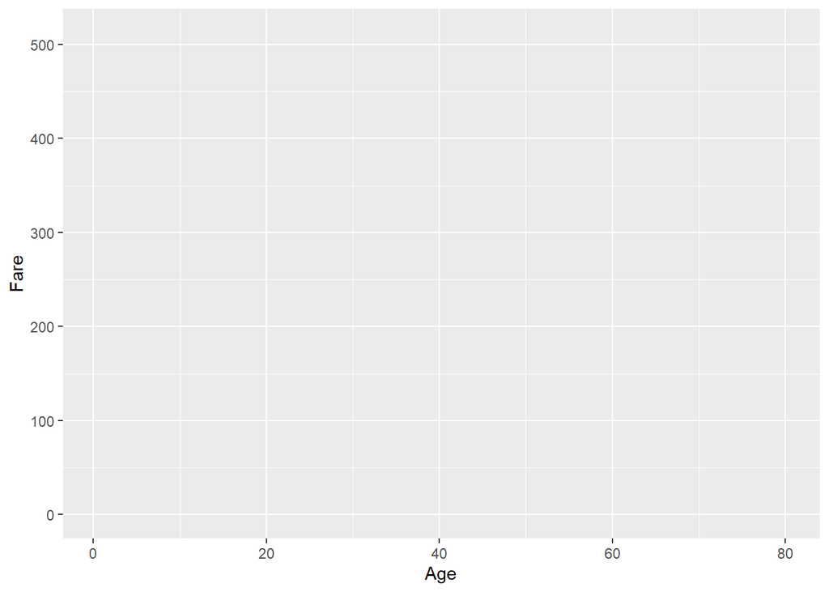

```r
ggplot(data, aes(x = Age, y = Fare))
```

## 7.2 Scatterplot (two continuous variables)

A scatterplot is the go-to plot when you want to see the **relationship between two continuous variables**: age and fare, income and education, screen time and sleep quality…

The principle: **each dot is one observation** (here, one passenger). Its horizontal position is given by the first variable (its age), and its vertical position by the second (the fare it paid). So the plot is simply the whole dataset, drawn as a cloud of dots.

We add a layer of points to our empty canvas:

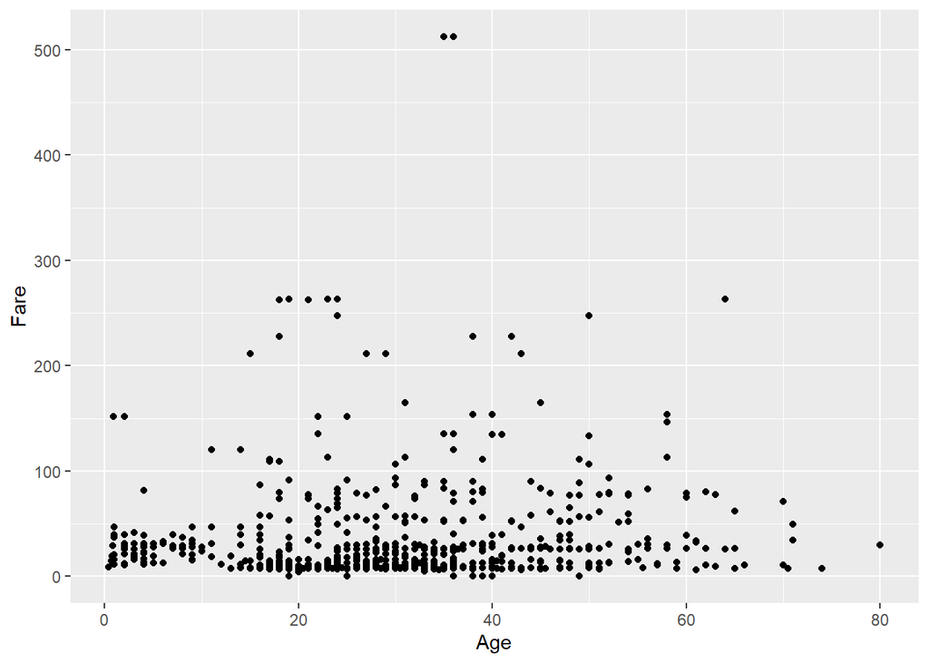

```r
ggplot(data, aes(x = Age, y = Fare)) +
  geom_point()
```

How to read a scatterplot? Look at the general shape of the cloud:

- If the cloud **goes up** from left to right, the two variables are positively associated: higher x, higher y.
- If it **goes down**, they are negatively associated.
- If it’s a **shapeless blob**, there is no clear association.
- Also look at **isolated dots**: here, a few passengers paid more than 500 £, far above everyone else.

Here, the cloud is mostly flat: older passengers didn’t clearly pay more than younger ones. Most dots are crushed at the bottom, because most passengers paid low fares.

## 7.3 Scatterplot with a regression line: `geom_smooth()`

It’s not always easy to see a trend in a cloud of dots, especially when there are many of them. `geom_smooth()` adds a line that summarizes the trend:

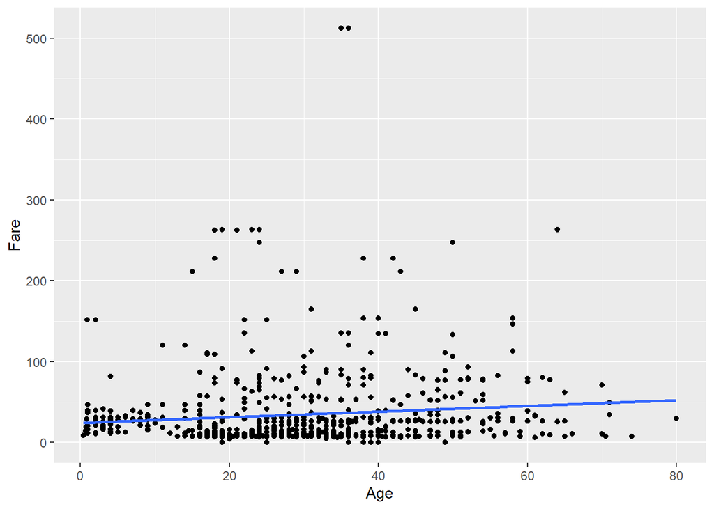

```r
ggplot(data, aes(x = Age, y = Fare)) +
  geom_point() +
  geom_smooth(method = "lm", se = FALSE) # "lm" = linear model
```

## 7.4 Color: mapping vs setting

Color can be used in two very different ways, and the difference is **whether you write it inside or outside `aes()`**.

**Inside `aes()`: the color *depends on a variable*.** This is called *mapping*. R gives each category its own color, and adds a legend to tell you which is which. Here, each passenger is colored according to their sex:

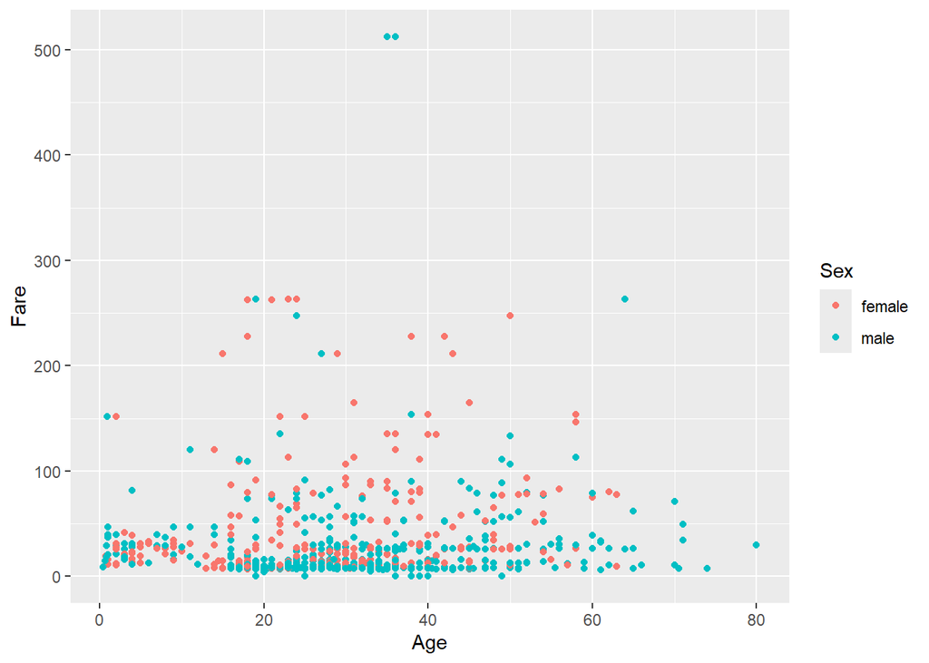

```r
ggplot(data, aes(x = Age, y = Fare, color = Sex)) +
  geom_point()
```

**Outside `aes()`: the color is *fixed*, for all the dots.** This is called *setting*. It’s just decoration: it carries no information, so there’s no legend.

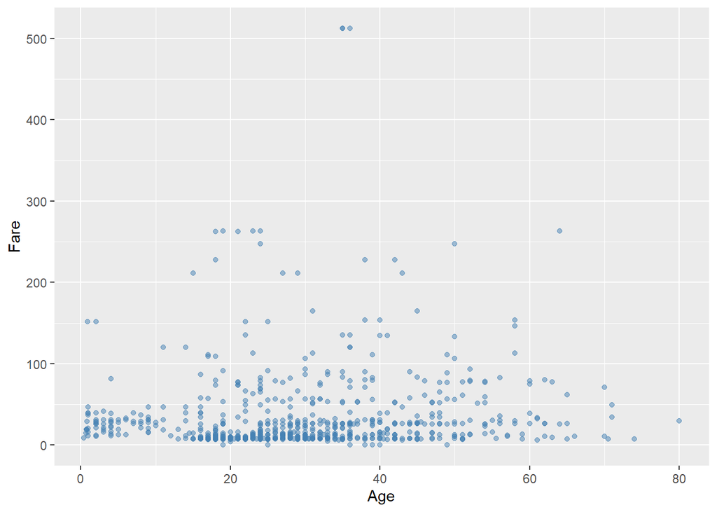

```r
ggplot(data, aes(x = Age, y = Fare)) +
  geom_point(color = "steelblue", alpha = 0.5) # alpha = transparency, from 0 (invisible) to 1 (opaque)
```

*NB: Transparency (`alpha`) is very useful when many dots overlap: the darker an area, the more passengers are stacked there.*

**The classic mistake: a fixed color inside `aes()`.** Look at what happens:

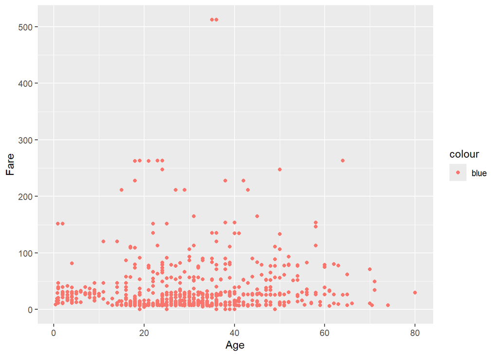

```r
ggplot(data, aes(x = Age, y = Fare, color = "blue")) +
  geom_point()
```

The dots are not blue, and there is a strange legend saying “blue”. Why? Because inside `aes()`, R expects a *variable*. It treats `"blue"` as a variable with one single category called “blue”, and gives it the first default color (red). Rule of thumb: **a variable name goes inside `aes()`; a color name goes outside.**

**Using color to compare trends between sub-groups.** This is where mapping becomes really powerful. If you map color to a variable *and* add `geom_smooth()`, ggplot fits **one line per group**. You can then directly compare the trends. For example: is the relationship between age and fare the same in each class?

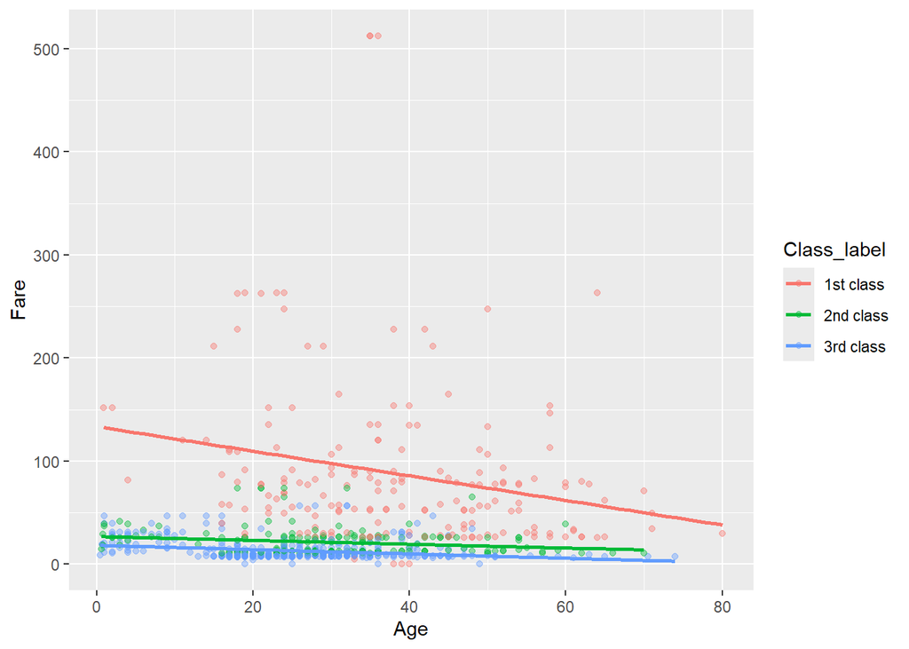

```r
ggplot(data, aes(x = Age, y = Fare, color = Class_label)) +
  geom_point(alpha = 0.4) +
  geom_smooth(method = "lm", se = FALSE)
```

Three lines, three classes. We immediately see that 1st class passengers paid much more at every age (the red line is far above the others). We also see that the trend is not the same everywhere: within the 1st class, the line clearly goes down (older passengers paid less), while in 2nd and 3rd class the lines are almost flat. This is exactly the kind of thing you would miss with a single line for all passengers.

Same thing with a 0/1 outcome: did the chance of survival change with age, and was it the same for men and women?

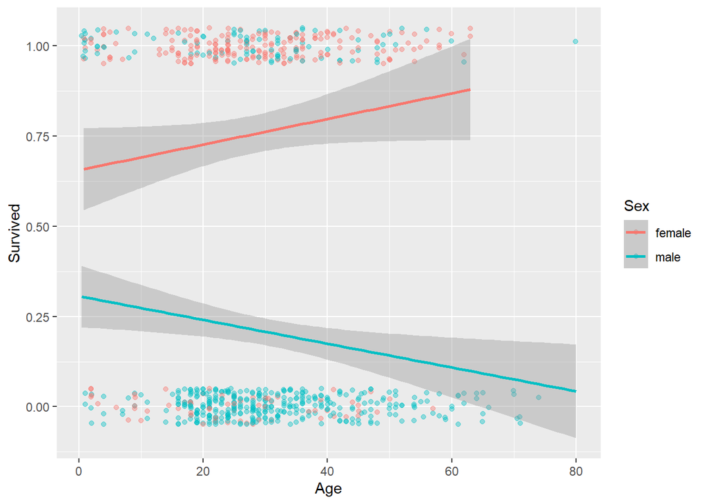

```r
ggplot(data, aes(x = Age, y = Survived, color = Sex)) +
  geom_jitter(height = 0.05, alpha = 0.4) + # like geom_point, but moves dots slightly so they don't overlap
  geom_smooth(method = "lm")
```

Women had a much higher chance of survival than men at all ages (the female line is far above the male one). For men, the line goes down: younger men were more likely to survive.

**Choosing your own colors.** By default, R chooses the colors. To choose them yourself, add `scale_color_manual()`, and give one color per category:

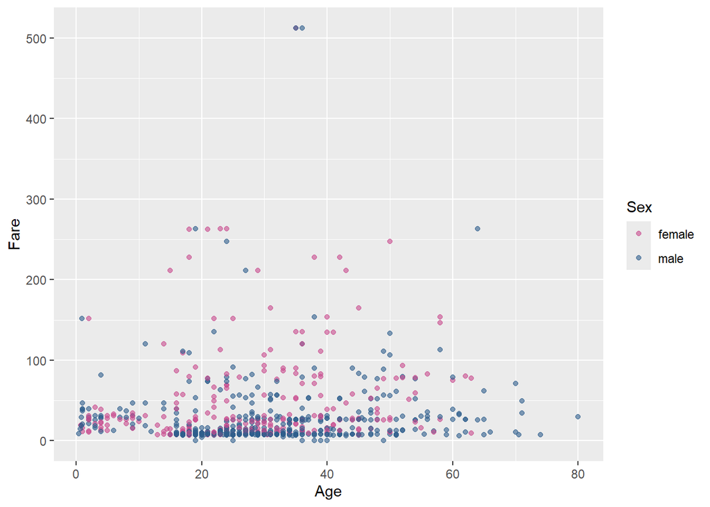

```r
ggplot(data, aes(x = Age, y = Fare, color = Sex)) +
  geom_point(alpha = 0.6) +
  scale_color_manual(values = c("female" = "#C84B8E", "male" = "#2E5E8C"))
```

*NB: `color` is for points and lines; `fill` is for the inside of bars and boxes. For bars and boxes, use `scale_fill_manual()` instead.*

## 7.5 Titles, axis labels, theme

A plot is made to be read by someone else. Variable names like `Pclass` or `Fare` are for R, not for readers. Use `labs()` to give each axis a clear name, **with its unit**:

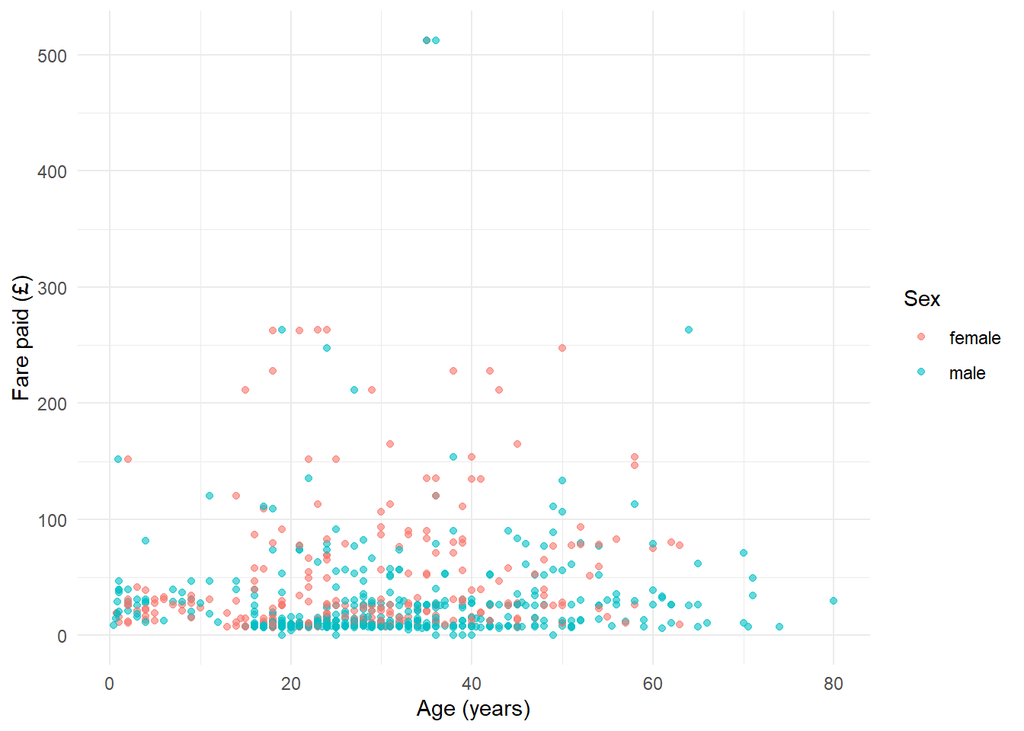

```r
ggplot(data, aes(x = Age, y = Fare, color = Sex)) +
  geom_point(alpha = 0.6) +
  labs(x = "Age (years)",
       y = "Fare paid (£)",
       color = "Sex") +   # title of the legend
  theme_minimal()         # a cleaner look. Also try theme_bw(), theme_classic()
```

## 7.6 Facets: one panel per category

Colors work well with 2 or 3 groups. With more groups, or when dots overlap too much, the plot becomes unreadable. The alternative: **facets**. Instead of drawing all groups on the same plot, ggplot draws the same plot several times, once for each category, side by side.

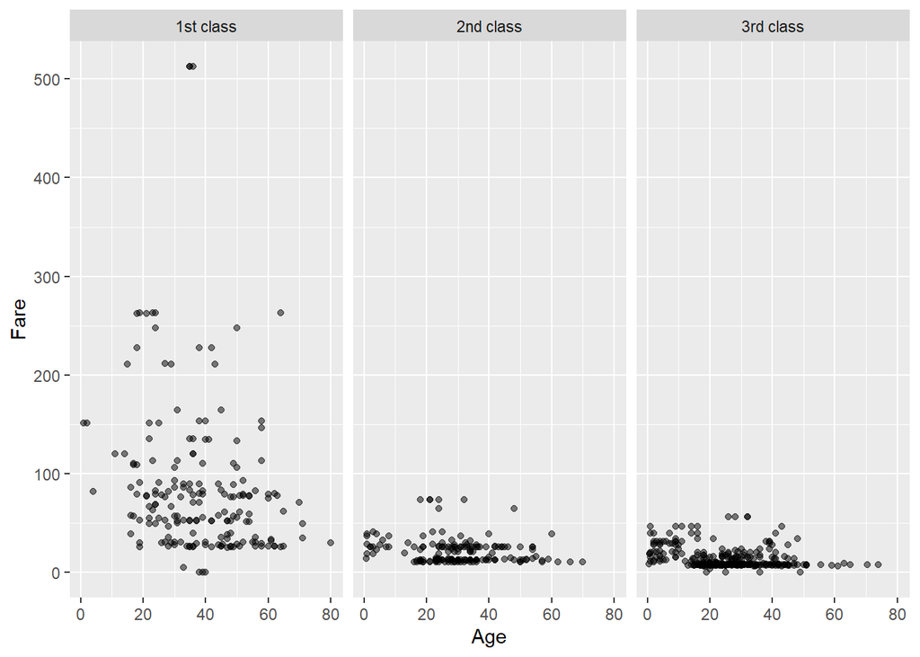

```r
ggplot(data, aes(x = Age, y = Fare)) +
  geom_point(alpha = 0.5) +
  facet_wrap(~ Class_label)
```

`facet_wrap(~ variable)`: one panel for each value of the variable after the `~`. Notice that all panels share the same axes, so you can compare them directly.

## 7.7 Bar chart of counts: `geom_bar()`

When your variable is a **category** (class, sex, port…), the simplest question is: how many observations in each category? A bar chart answers it visually: one bar per category, and the height of the bar is the number of observations.

`geom_bar()` does the counting for you. You only give an `x`:

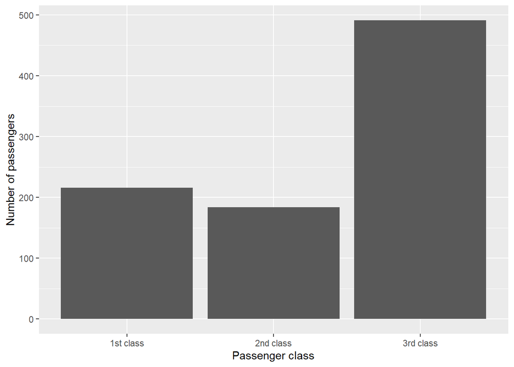

```r
ggplot(data, aes(x = Class_label)) +
  geom_bar() +
  labs(x = "Passenger class", y = "Number of passengers")
```

This is the visual equivalent of *group_by(Class_label) %>% count().*

**Bars sorted from highest to lowest.** By default, bars follow the order of the categories. To sort them by frequency, wrap the variable in `fct_infreq()`:

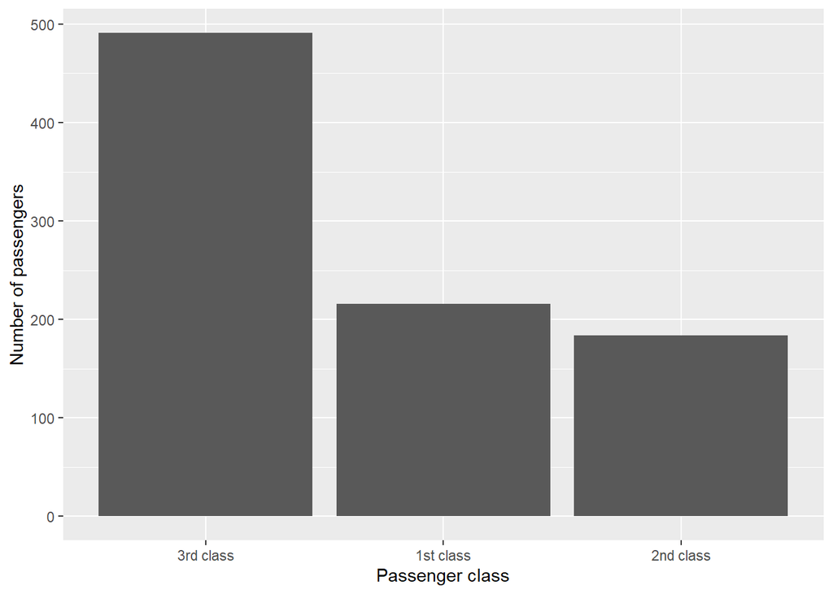

```r
ggplot(data, aes(x = fct_infreq(Class_label))) +
  geom_bar() +
  labs(x = "Passenger class", y = "Number of passengers")
```

**Bars split by another variable.** Map `fill` to a second variable to see its composition within each bar. Here: within each class, what share of passengers survived?

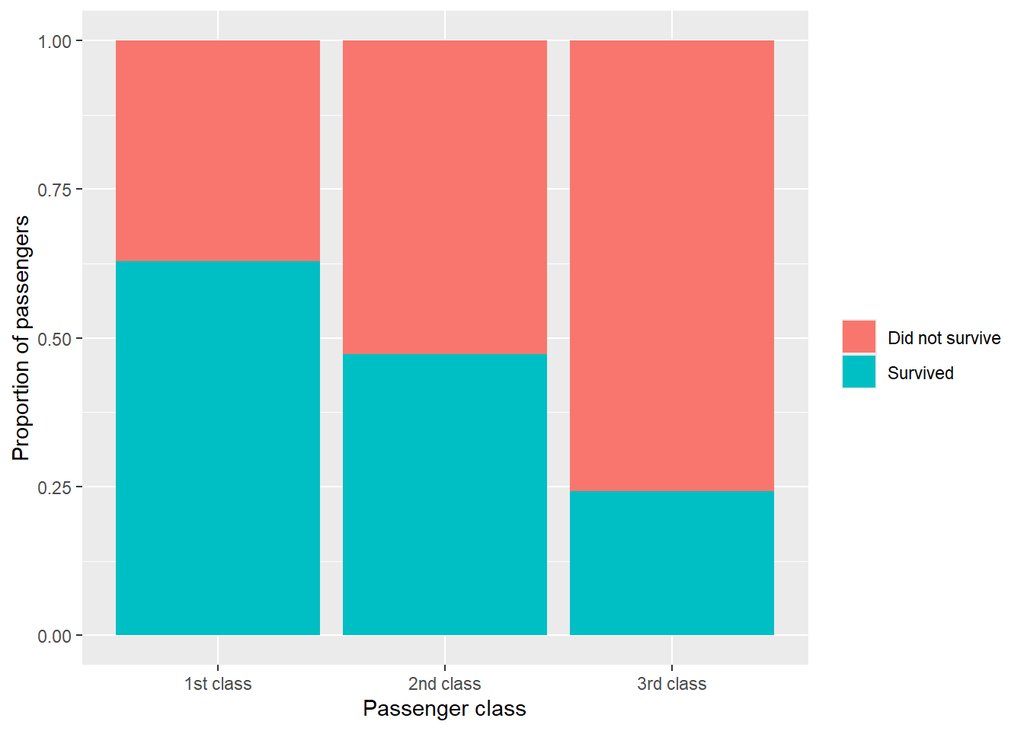

```r
ggplot(data, aes(x = Class_label, fill = Survived_label)) +
  geom_bar(position = "fill") + # "fill" = proportions (each bar goes up to 1)
  labs(x = "Passenger class", y = "Proportion of passengers", fill = "")
```

With `position = "fill"`, every bar has the same height (100%), so you compare *proportions*, not raw numbers. This is what you want here, since the classes don’t have the same size. Try also `position = "dodge"` (bars side by side) and removing `position` (bars stacked, in counts) to see the difference.

## 7.8 Bar chart of values you computed: `geom_col()`

Sometimes you’ve already computed the numbers you want to plot, for instance a survival rate with `summarise()`. Then you don’t want ggplot to count rows: you want it to draw bars *of the height you computed*. That’s `geom_col()`, and this time you give both `x` and `y`.

The code below does it in one go: compute the survival rate by class, then pipe the resulting table into ggplot.

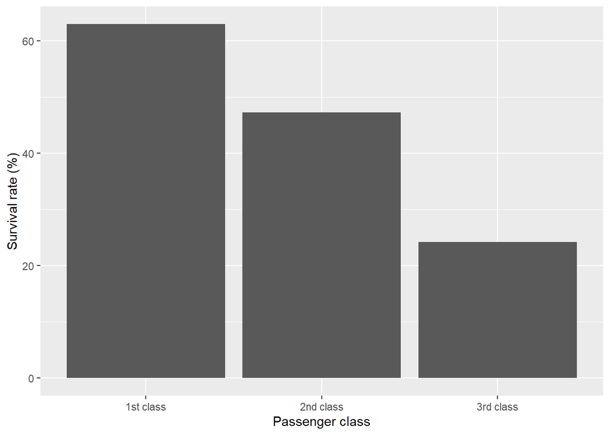

```r
data %>%
  group_by(Class_label) %>%
  summarise(survival_rate = mean(Survived) * 100) %>%
  ggplot(aes(x = Class_label, y = survival_rate)) +
  geom_col() +
  labs(x = "Passenger class", y = "Survival rate (%)")
```

*NB: Notice the switch: `%>%` until `ggplot()`, then `+` after. The pipe passes the table to ggplot; inside ggplot, layers are added with `+`.*

## 7.9 Distribution of one variable: histogram

Often, before looking at relationships, we want to see how *one* continuous variable is distributed: are most passengers young? Is there a peak? Are there extreme values? A histogram answers this.

The principle: the x-axis is cut into intervals (“bins”), and each bar shows how many observations fall in that interval.

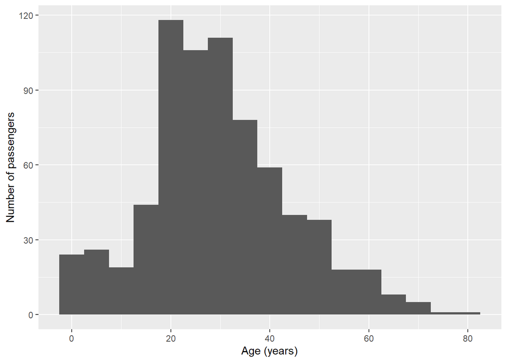

```r
ggplot(data, aes(x = Age)) +
  geom_histogram(binwidth = 5) +
  labs(x = "Age (years)", y = "Number of passengers")
```

Here `binwidth = 5`: each bar covers 5 years (0–5, 5–10, …). The plot shows that most passengers were between 20 and 40, with a small bump of young children. Change `binwidth` and see how the picture changes: too wide and you lose details, too narrow and it becomes noisy.

**Comparing distributions between groups.** Add facets to draw one histogram per group:

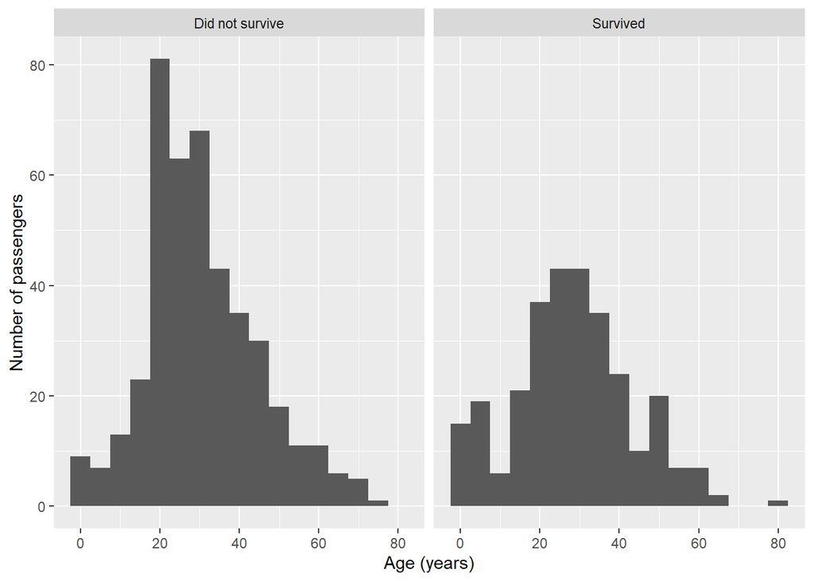

```r
ggplot(data, aes(x = Age)) +
  geom_histogram(binwidth = 5) +
  facet_wrap(~ Survived_label) +
  labs(x = "Age (years)", y = "Number of passengers")
```

## 7.10 Distribution by group: boxplot

A boxplot is another way to compare the distribution of a continuous variable between groups, more compact than histograms. It summarizes each group’s distribution with a few key values.

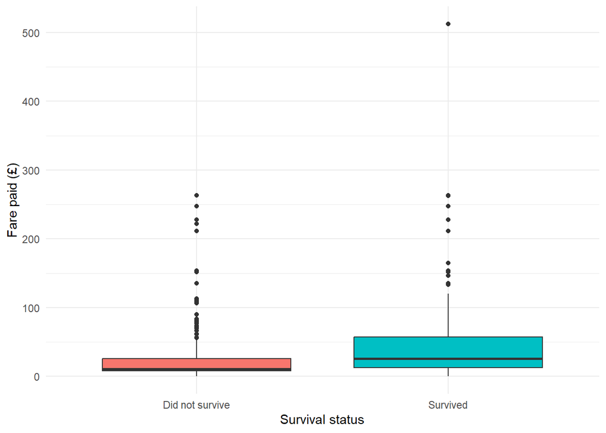

```r
ggplot(data, aes(x = Survived_label, y = Fare, fill = Survived_label)) +
  geom_boxplot() +
  labs(x = "Survival status", y = "Fare paid (£)") +
  theme_minimal() +
  theme(legend.position = "none") # the legend is useless: the x-axis already says it
```

**How to read a boxplot:**

- The **thick line** inside the box is the **median**: half the passengers paid less, half paid more.
- The **bottom of the box** is the **first quartile**: 25% of passengers paid less than that.
- The **top of the box** is the **third quartile**: 25% paid more than that.
- So **the box contains the middle 50%** of passengers. Its height is called the **interquartile range (IQR)**.
- The **whiskers** stretch out to the furthest passengers who are still within 1.5 IQRs of the box.
- Anyone further out is plotted as an **individual dot**, and is conventionally called an **outlier**.

**Reading this plot:** the median fare of survivors is clearly higher than that of non-survivors, and the whole box is shifted upward. Survivors tended to have paid more.

## 7.11 A line over an ordered variable: `geom_line()`

Lines are used when the x-axis has a natural **order**, and you want to see how something evolves along it: typically time (years, months), but also any ordered categories. Titanic has no time variable, so here we look at how the survival rate evolves across age groups (the `Age_decade` variable we created with `cut()`).

First we compute the survival rate in each age group, then we draw it, with points for each group and a line connecting them:

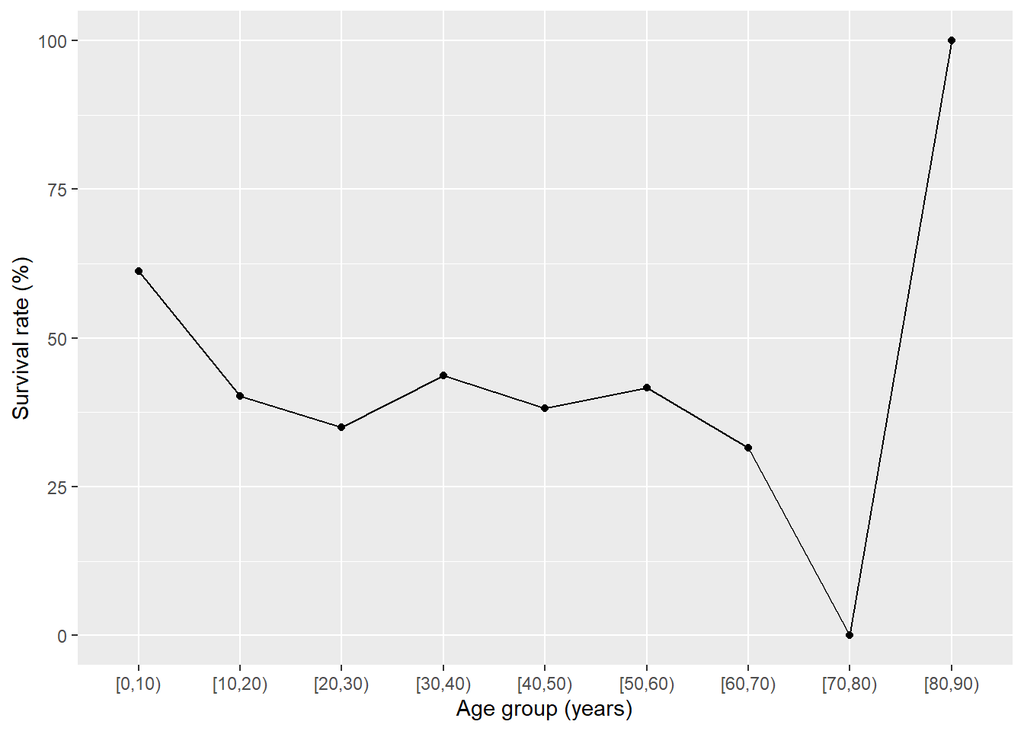

```r
data %>%
  filter(!is.na(Age_decade)) %>%
  group_by(Age_decade) %>%
  summarise(survival_rate = mean(Survived) * 100) %>%
  ggplot(aes(x = Age_decade, y = survival_rate, group = 1)) + # group = 1: connect all points with one line
  geom_line() +
  geom_point() +
  labs(x = "Age group (years)", y = "Survival rate (%)")
```

Children under 10 had a much higher survival rate than the other groups. But look at the end of the line: it drops to 0% for the 70–79, then jumps to 100% for the 80–89. Does that mean being 80 was a great protection? No: there are only 6 passengers in their 70s, and **one single passenger** over 80. A percentage based on one person means nothing.

*NB: This is why you should always check how many observations each percentage is based on (with `n()`, see the Descriptive statistics section), before interpreting a plot.*

## 7.12 Save a plot as a file

In a .qmd, plots appear automatically in the rendered document. If you need the plot as a separate image (e.g. for a slide), use `ggsave()` right after the plot:

```r
ggsave("my_plot.png", width = 7, height = 5) # saves the LAST plot, in the working directory
```

# 8. Data transformation (advanced, seen in TD3)

The functions in this section are less frequent, but you’ll need them as soon as you work with real, messy data (like the Qualtrics data of TD 3). All examples below still use Titanic.

## 8.1 Remove specific rows by position: `slice()`

Sometimes the problem is not a *value* but a *position*: specific rows that should not be there at all. Typical case: Qualtrics exports add two junk rows at the top of the dataset (the question wording, and internal IDs). They are not participants, so we remove them by their position:

```r
data = data %>%
  slice(-c(1, 2)) # removes rows 1 and 2
```

The minus sign means “everything except”. `slice(1:10)`, without minus, would keep only the first 10 rows.

## 8.2 Convert several variables at once: `across()`

With Qualtrics data, numbers often arrive stored as text. Converting them one by one with `as.numeric()` gets long. `across()` applies the same function to several columns at once:

```r
data = data %>%
  mutate(across(c(Age, Fare, SibSp, Parch), as.numeric))
```

Read it as: “modify, across these four columns, by applying `as.numeric`”.

## 8.3 Remove extreme values (± 3 standard deviations)

Some observations are so extreme that they may be errors, or may distort your results (a participant who took 3 hours to answer a 10-minute survey, for instance). A common rule is to remove observations more than 3 standard deviations away from the mean.

We proceed in two steps. First, compute the mean and the standard deviation, and store them:

```r
fare_mean = mean(data$Fare, na.rm = TRUE)
fare_sd   = sd(data$Fare, na.rm = TRUE)
```

Then keep only the passengers whose fare is between “mean − 3 SD” and “mean + 3 SD”, and check how many were removed:

```r
data_no_extremes = data %>%
  filter(Fare >= fare_mean - 3 * fare_sd,
         Fare <= fare_mean + 3 * fare_sd)

nrow(data) - nrow(data_no_extremes) # number of passengers removed
```

```
[1] 20
```

*NB: Removing extreme values is a decision, and it must be justified and reported. Never do it silently.*

## 8.4 Split one column into several: `separate()`

Sometimes, one column contains several pieces of information. Look at the `Name` variable:

```r
head(data$Name, 3)
```

```
[1] "Braund, Mr. Owen Harris"
[2] "Cumings, Mrs. John Bradley (Florence Briggs Thayer)"
[3] "Heikkinen, Miss. Laina"
```

Each name follows the same structure: `Last name, Title. First names`. The title (Mr, Mrs, Miss, Master…) is actually an interesting variable: it tells us about sex, age and marital status. But it’s stuck inside the name. `separate()` cuts a column into several columns, wherever a separator appears.

Step 1: cut at the comma, to isolate the last name:

```r
data_names = data %>%
  separate(col = Name,
           into = c("Last_name", "Rest"), # the names of the new columns
           sep = ", ",                    # where to cut
           extra = "merge")               # if there are more cuts than expected, keep the rest together
```

Step 2: cut `Rest` at the first period, to isolate the title:

```r
data_names = data_names %>%
  separate(col = Rest,
           into = c("Title", "First_names"),
           sep = "\\. ",  # a period followed by a space. The "\\" is needed because "." has a special meaning in R
           extra = "merge")

data_names %>%
  select(Last_name, Title, First_names) %>%
  head()
```

| Last_name | Title | First_names |
| --- | --- | --- |
| Braund | Mr | Owen Harris |
| Cumings | Mrs | John Bradley (Florence Briggs Thayer) |
| Heikkinen | Miss | Laina |
| Futrelle | Mrs | Jacques Heath (Lily May Peel) |
| Allen | Mr | William Henry |
| Moran | Mr | James |

Now `Title` is a variable like any other. We can, for instance, look at survival by title:

```r
data_names %>%
  group_by(Title) %>%
  summarise(survival_rate = mean(Survived) * 100,
            n = n()) %>%
  arrange(desc(n))
```

| Title | survival_rate | n |
| --- | --- | --- |
| Mr | 15.66731 | 517 |
| Miss | 69.78022 | 182 |
| Mrs | 79.20000 | 125 |
| Master | 57.50000 | 40 |
| Dr | 42.85714 | 7 |
| Rev | 0.00000 | 6 |
| Col | 50.00000 | 2 |
| Major | 50.00000 | 2 |
| Mlle | 100.00000 | 2 |
| Capt | 0.00000 | 1 |
| Don | 0.00000 | 1 |
| Jonkheer | 0.00000 | 1 |
| Lady | 100.00000 | 1 |
| Mme | 100.00000 | 1 |
| Ms | 100.00000 | 1 |
| Sir | 100.00000 | 1 |
| the Countess | 100.00000 | 1 |

*NB: In TD 3, `separate()` was used the same way to cut the `results` column into 8 variables, with `sep = ","`. Add `convert = TRUE` if the new columns contain numbers: R will convert them automatically.*

## 8.5 One cell contains several values → one row per value: `separate_rows()`

A tidy dataset follows one rule: **one value per cell**. Look at the `Cabin` variable: some passengers booked several cabins, and they are all stored in the same cell.

```r
data %>%
  filter(PassengerId == 28) %>%
  select(PassengerId, Name, Cabin)
```

| PassengerId | Name | Cabin |
| --- | --- | --- |
| 28 | Fortune, Mr. Charles Alexander | C23 C25 C27 |

`separate_rows()` unpacks such cells: it creates one row per value, and repeats all the other information (name, age, etc.) on each new row.

```r
data_cabins = data %>%
  separate_rows(Cabin, sep = " ")

data_cabins %>%
  filter(PassengerId == 28) %>%
  select(PassengerId, Name, Cabin)
```

| PassengerId | Name | Cabin |
| --- | --- | --- |
| 28 | Fortune, Mr. Charles Alexander | C23 |
| 28 | Fortune, Mr. Charles Alexander | C25 |
| 28 | Fortune, Mr. Charles Alexander | C27 |

One passenger, three cabins → three rows. Careful: the meaning of a row has changed! In `data_cabins`, each row is now a *cabin*, not a passenger. That’s why we save it in a new object, and keep `data` intact.

*NB: In TD 3, each participant’s `results` cell contained all their trials, separated by `;`. `separate_rows()` gave one row per trial.*

## 8.6 From long to wide: `pivot_wider()`

When you group by two variables, the result is “long”: one row per combination.

```r
data %>%
  group_by(Class_label, Sex) %>%
  summarise(survival_rate = mean(Survived))
```

| Class_label | Sex | survival_rate |
| --- | --- | --- |
| 1st class | female | 0.9680851 |
| 1st class | male | 0.3688525 |
| 2nd class | female | 0.9210526 |
| 2nd class | male | 0.1574074 |
| 3rd class | female | 0.5000000 |
| 3rd class | male | 0.1354467 |

Six rows, hard to compare at a glance. It would be easier to read with one row per class, and one column per sex. That’s `pivot_wider()`: it takes the categories of one variable (`names_from`) and turns them into columns, filled with the values of another variable (`values_from`).

```r
data %>%
  group_by(Class_label, Sex) %>%
  summarise(survival_rate = mean(Survived)) %>%
  pivot_wider(names_from = Sex, values_from = survival_rate)
```

| Class_label | female | male |
| --- | --- | --- |
| 1st class | 0.9680851 | 0.3688525 |
| 2nd class | 0.9210526 | 0.1574074 |
| 3rd class | 0.5000000 | 0.1354467 |

Same information, but now men and women of the same class are on the same row. Beyond readability, this is useful when you need to compute something *between* two conditions, row by row (in TD 3: the difference between Harsh and Lenient trials for each participant):

```r
data %>%
  group_by(Class_label, Sex) %>%
  summarise(survival_rate = mean(Survived)) %>%
  pivot_wider(names_from = Sex, values_from = survival_rate) %>%
  mutate(gap = female - male) # survival gap between women and men, in each class
```

| Class_label | female | male | gap |
| --- | --- | --- | --- |
| 1st class | 0.9680851 | 0.3688525 | 0.5992326 |
| 2nd class | 0.9210526 | 0.1574074 | 0.7636452 |
| 3rd class | 0.5000000 | 0.1354467 | 0.3645533 |

## 8.7 Merge two datasets: `left_join()`

Sometimes the information you need is spread across two datasets, linked by a common identifier (a participant ID, a country code…). `left_join()` merges them.

Example: in Titanic, `Embarked` only contains a letter (C, Q, S). Suppose we have a second, small table with the full name of each port:

```r
ports = data.frame(Embarked = c("C", "Q", "S"),
                   Port = c("Cherbourg", "Queenstown", "Southampton"))
ports
```

| Embarked | Port |
| --- | --- |
| C | Cherbourg |
| Q | Queenstown |
| S | Southampton |

We can merge it into our main dataset, using `Embarked` as the common identifier:

```r
data = data %>%
  left_join(ports, by = "Embarked")

data %>%
  select(Name, Embarked, Port) %>%
  head()
```

| Name | Embarked | Port |
| --- | --- | --- |
| Braund, Mr. Owen Harris | S | Southampton |
| Cumings, Mrs. John Bradley (Florence Briggs Thayer) | C | Cherbourg |
| Heikkinen, Miss. Laina | S | Southampton |
| Futrelle, Mrs. Jacques Heath (Lily May Peel) | S | Southampton |
| Allen, Mr. William Henry | S | Southampton |
| Moran, Mr. James | Q | Queenstown |

How it works: for each row of `data` (the “left” dataset), R looks for the same value of `Embarked` in `ports`, and adds its columns. Every row of `data` is kept, even if no match is found: then the new columns get `NA` (here, the two passengers with no port).

*NB: In TD 3, `left_join()` added each participant’s subjective wealth (from the participant-level data) to their threat reactivity score, using `ResponseId` as the common identifier.*

# 9. Common error messages (and what they actually mean)

| Error | What it means | What to do |
| --- | --- | --- |
| `could not find function "..."` | The package is not loaded, or you misspelled the function | Run `library(tidyverse)`; check spelling |
| `object '...' not found` | The object doesn’t exist (yet) | Did you run the chunk that creates it? Is the name spelled exactly the same (capitals!)? |
| `cannot open file '...': No such file or directory` | R can’t find your dataset | Check `getwd()`. Is the file in that folder? Is the name exactly right, with `.csv`? |
| The result is `NA` | There are missing values | Add `na.rm = TRUE` |
| `non-numeric argument` / `argument is not numeric or logical` | The variable is stored as text | Convert it with `as.numeric()` |
| `unexpected symbol` / `unexpected ')'` | A typo: missing comma, parenthesis, or quote | Look at the line indicated; count your parentheses |
| It works in RStudio but not when rendering | Your code depends on something you did by hand, outside the .qmd | Restart R and run everything from the top (see advice below) |
| `+` appears in the console and nothing happens | R is waiting for the end of your command (a missing `)` or `"`) | Press Esc, then fix the code |

# 10. Advice

**Restart R and run your code from the very beginning, often.** Especially if you’ve done a lot of data transformation. After many `data = data %>% ...`, your `data` may not be what you think it is anymore. Session → Restart R, then run all chunks from the top. If it works this way, it will render.

**Look at your data after each transformation.** A `glimpse()`, a `count()`, a quick `View()`. Don’t trust that the code did what you wanted: check it.

**When stuck, start from a piece of code that works** (in this document, in a previous TD) and modify it step by step.

**Read the error message.** It’s often more helpful than it looks. Copy-paste it into a search engine if needed.

**Name things clearly.** `women_first_class` is better than `data2`.

**Comment your code** with `#`. You will thank yourself in two weeks.

*(more to come)*